# BE1 Notebook

Exercice 1 ## On commence par lire et visualiser les données du fichier

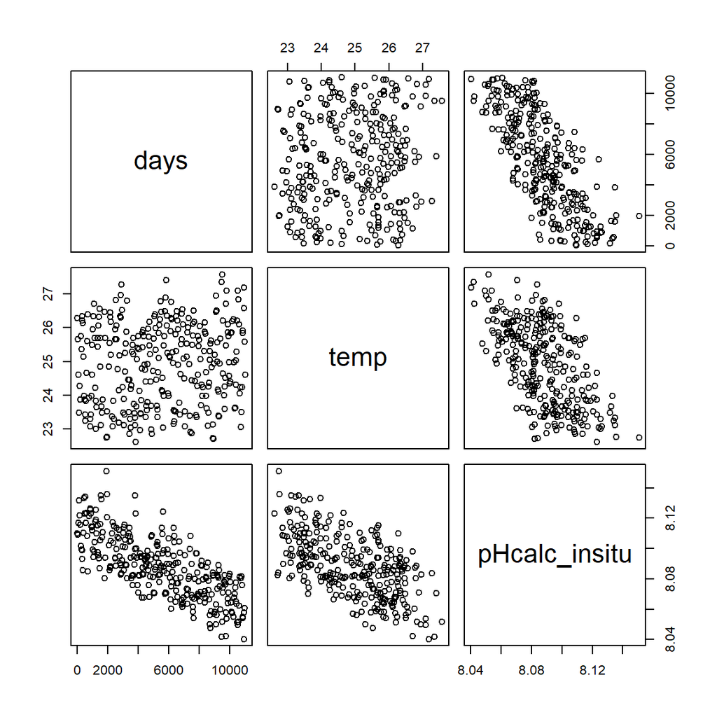

```r
PH = read.table(file = "ph.txt", header = TRUE, dec=",", sep = "\t")
pairs(PH)
```

1)a)

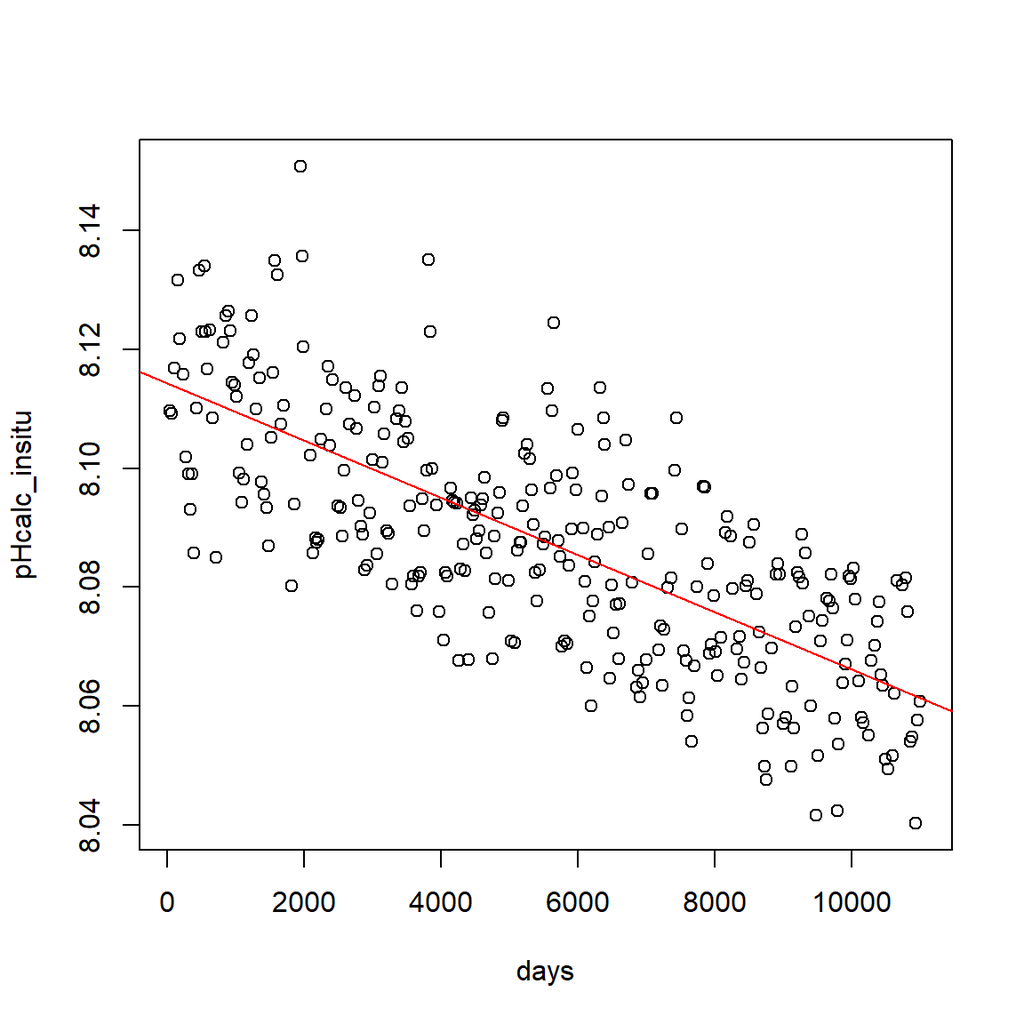

```r
mod = lm(pHcalc_insitu~days, data = PH)
plot(pHcalc_insitu~days, data = PH)
abline(mod$coefficients, col = 'red')
```

1)b)

```r
summary(mod)
```

```
##
## Call:
## lm(formula = pHcalc_insitu ~ days, data = PH)
##
## Residuals:
##       Min        1Q    Median        3Q       Max
## -0.026969 -0.010493 -0.000187  0.010587  0.045919
##
## Coefficients:
##               Estimate Std. Error t value Pr(>|t|)
## (Intercept)  8.114e+00  1.597e-03 5079.97   <2e-16 ***
## days        -4.801e-06  2.520e-07  -19.05   <2e-16 ***
## ---
## Signif. codes:  0 '***' 0.001 '**' 0.01 '*' 0.05 '.' 0.1 ' ' 1
##
## Residual standard error: 0.01359 on 297 degrees of freedom
##   (9 observations effacées parce que manquantes)
## Multiple R-squared:  0.5499, Adjusted R-squared:  0.5484
## F-statistic: 362.9 on 1 and 297 DF,  p-value: < 2.2e-16
```

Le modèle est globalement significatif (IC de 99%) d’après le test de Fisher : p-value<0.01 Le pourcentage de la variance expliquée par le modèle correspond au R-squared : le modèle permet d’expliquer 55% de la variance du PH

1)c) On teste l’hypothèse nulle suivante : $\beta_{1} = 0$ où $_{1} $ représente le coefficient associé au facteur “days”. Si ce coefficient est nul (si HO vérifiée), cela signifie que la variable days n’a pas d’impact significatif sur le PH. H1 = $\beta_{1} \neq 0$

```r
nouvel_individu = data.frame(days = 19000)
prediction = predict(mod, newdata = nouvel_individu)
prediction
```

```
##        1
## 8.022966
```

Intervale de confiance de la valeur moyenne de la prédiction:

```r
prediction_IC = data.frame(predict(mod, newdata = nouvel_individu, interval = 'confidence', level = 0.95))
prediction_IC
```

```
##        fit      lwr      upr
## 1 8.022966 8.016103 8.029829
```

Donc, d’après ce modèle, le PH moyen prévu en 2050 est de 8.022966 et sera compris entre 8.016103 et 8.029829 avec une confiance de 95%.

```r
prediction_IP = data.frame(predict(mod, newdata = nouvel_individu, interval = 'prediction', level = 0.95))
prediction_IP
```

```
##        fit      lwr      upr
## 1 8.022966 7.995358 8.050575
```

Nous ne pouvons donc pas affirmer, avec une confiance de 95%, que le PH en 2050 sera supérieur à 8 car l’intervale de prédiction à 95% est : [7.995358, 8.050575 ]. Bilan 2) et 3) : Cela signifie qu’en moyenne, le PH mesuré en 2050 sera supérieur à 8%, mais qu’il existe des observations pour lequelles le PH sera inférieur à 8% (le tout pour une confiance de 95%)

4. On observe que les résidus sont répartis uniformément en fonction du PH. On observe trois résidus positifs importants pour des valeurs de PH supérieures à 8.08, mais aucune tendance claire se dessine : les résidus sont acceptables.

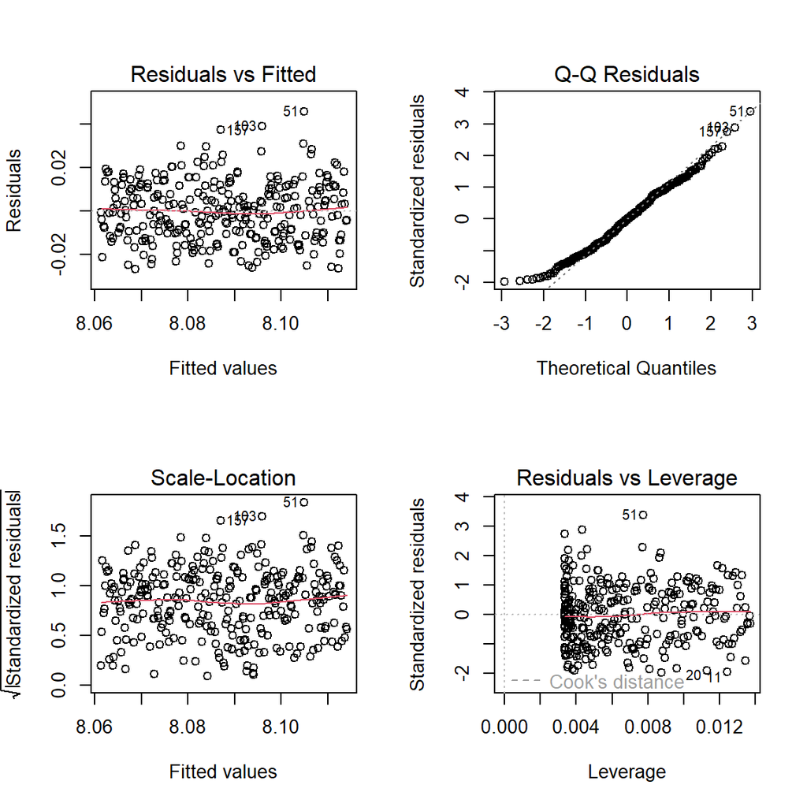

```r
par(mfrow=c(2,2))
plot(mod)
```

5) On reprend un raisonnement similaire avec la variable “temp”. On trace la droite de regression, on y décerne une légère tendance positive. Nous allons ensuite tester si cette tendance est significative pour une confiance de 95%.

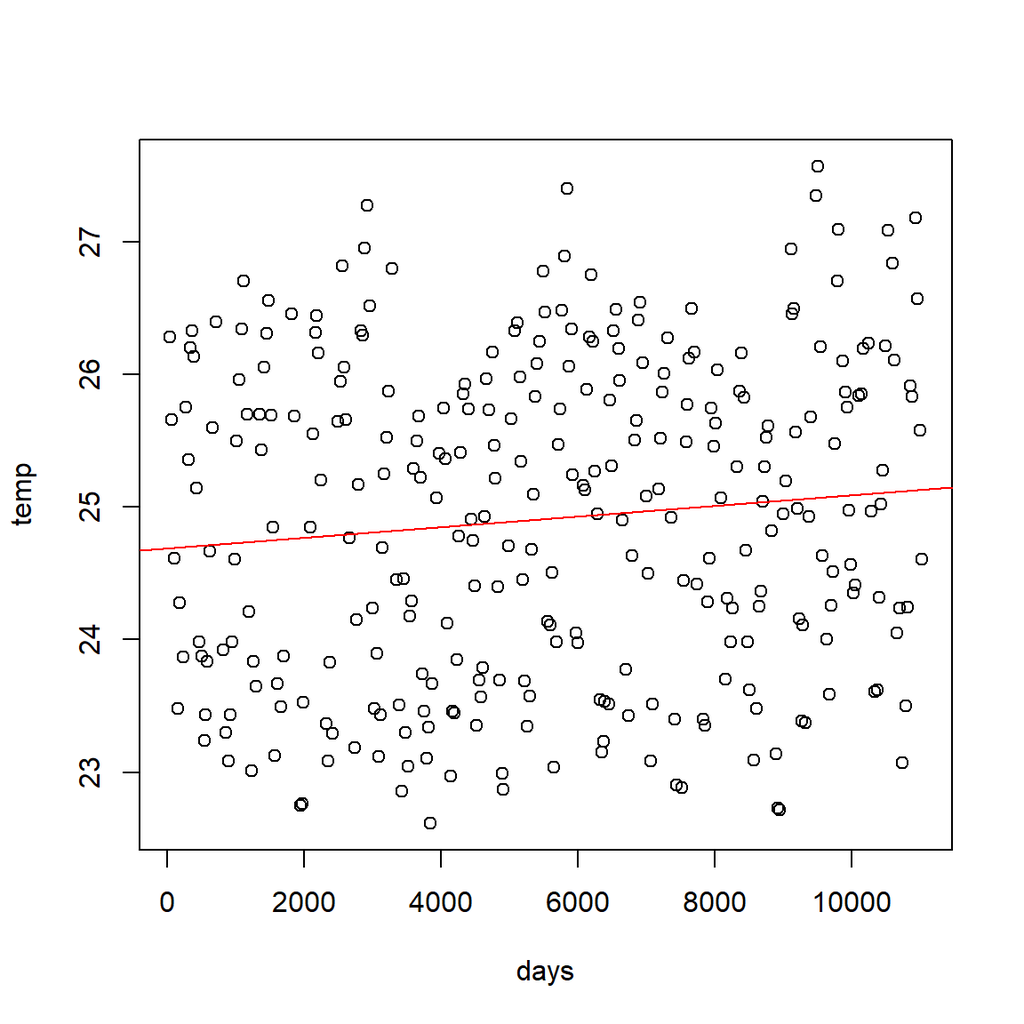

```r
mod2 = lm(temp~days, data = PH)
plot(temp~days, data = PH)
abline(mod2$coefficients, col = 'red')
```

```r
summary(mod2)
```

```
##
## Call:
## lm(formula = temp ~ days, data = PH)
##
## Residuals:
##      Min       1Q   Median       3Q      Max
## -2.33490 -1.04339  0.05254  0.98183  2.49979
##
## Coefficients:
##              Estimate Std. Error t value Pr(>|t|)
## (Intercept) 2.469e+01  1.399e-01  176.49   <2e-16 ***
## days        4.013e-05  2.193e-05    1.83   0.0682 .
## ---
## Signif. codes:  0 '***' 0.001 '**' 0.01 '*' 0.05 '.' 0.1 ' ' 1
##
## Residual standard error: 1.194 on 300 degrees of freedom
##   (6 observations effacées parce que manquantes)
## Multiple R-squared:  0.01104,    Adjusted R-squared:  0.007743
## F-statistic: 3.349 on 1 and 300 DF,  p-value: 0.06825
```

La modèle n’est globalement pas significatif (IC à 95%) car la p-value du test de Fisher est supérieure à 0.05: l’association entre les dates et la température de l’océan, telle qu’estimée par le modèle de régression, n’est pas significativement différente de zéro. Cela ne signifie pas forcément que le date n’a pas d’impact, mais qu’il faudrait peut être ajouter d’autres variables explicative ou augmenter le nombre de données.

Exercice 2

```r
Housing = read.table(file = "housing_new.txt",sep = "\t", dec = '.',header = TRUE)
head(Housing)
```

```
##    CRIM ZN INDUS CHAS   NOX    RM  AGE   DIS RAD TAX PTRATIO LSTAT class
## 1 0.006 18  2.31    0 0.538 6.575 65.2 4.090   1 296    15.3  4.98  24.0
## 2 0.027  0  7.07    0 0.469 6.421 78.9 4.967   2 242    17.8  9.14  21.6
## 3 0.027  0  7.07    0 0.469 7.185 61.1 4.967   2 242    17.8  4.03  34.7
## 4 0.032  0  2.18    0 0.458 6.998 45.8 6.062   3 222    18.7  2.94  33.4
## 5 0.069  0  2.18    0 0.458 7.147 54.2 6.062   3 222    18.7  5.33  36.2
## 6 0.030  0  2.18    0 0.458 6.430 58.7 6.062   3 222    18.7  5.21  28.7
```

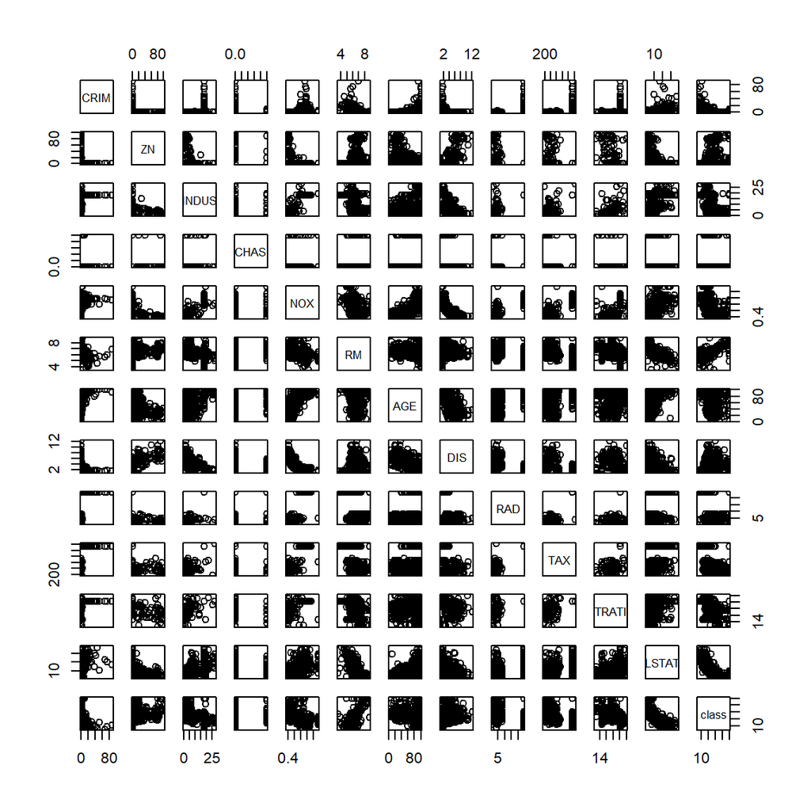

```r
pairs(Housing)
```

```r
mod1 = lm(class ~ ., data = Housing)
summary(mod1)
```

```
##
## Call:
## lm(formula = class ~ ., data = Housing)
##
## Residuals:
##      Min       1Q   Median       3Q      Max
## -15.1299  -2.7673  -0.5816   1.9411  26.2520
##
## Coefficients:
##               Estimate Std. Error t value Pr(>|t|)
## (Intercept)  41.617992   4.936061   8.431 3.79e-16 ***
## CRIM         -0.121391   0.033000  -3.678 0.000260 ***
## ZN            0.046962   0.013879   3.384 0.000772 ***
## INDUS         0.013462   0.062145   0.217 0.828591
## CHAS          2.840102   0.870005   3.264 0.001173 **
## NOX         -18.758738   3.851359  -4.871 1.50e-06 ***
## RM            3.658127   0.420244   8.705  < 2e-16 ***
## AGE           0.003610   0.013329   0.271 0.786658
## DIS          -1.490767   0.201622  -7.394 6.17e-13 ***
## RAD           0.289397   0.066908   4.325 1.84e-05 ***
## TAX          -0.012681   0.003801  -3.336 0.000913 ***
## PTRATIO      -0.937562   0.132207  -7.092 4.62e-12 ***
## LSTAT        -0.552013   0.050659 -10.897  < 2e-16 ***
## ---
## Signif. codes:  0 '***' 0.001 '**' 0.01 '*' 0.05 '.' 0.1 ' ' 1
##
## Residual standard error: 4.798 on 493 degrees of freedom
## Multiple R-squared:  0.7343, Adjusted R-squared:  0.7278
## F-statistic: 113.5 on 12 and 493 DF,  p-value: < 2.2e-16
```

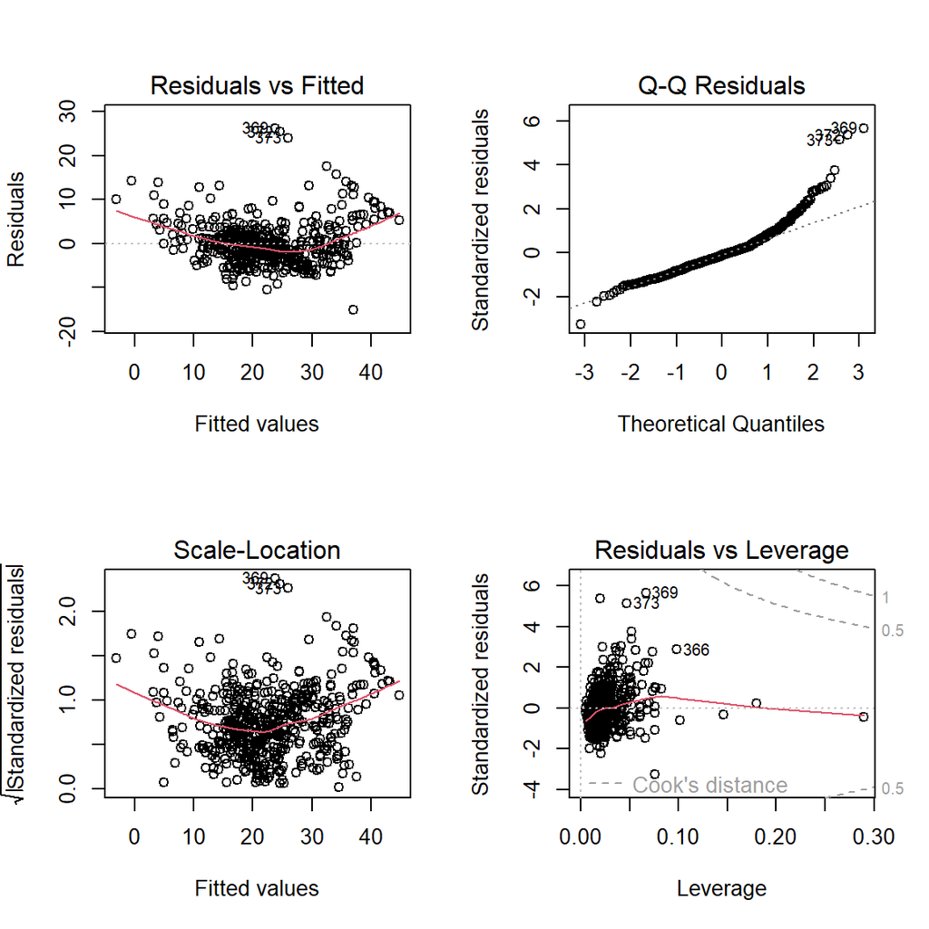

```r
par(mfrow=c(2,2))
plot(mod1)
```

1/ La part de variance expliquée par ce modèle est le “Multiple R-squared: 0.7343” 2/ Hypothèse : H₀ : “Tous les coefficients de régression sont égaux à zéro. Autrement dit, aucune des variables explicatives (indépendantes) n’a un effet significatif sur la variable dépendante, et le modèle de régression ne fournit pas une meilleure explication des variations de la variable cible que le modèle sans variable explicative (modèle”intercept seul”).” Statistique du test : la statistique F : “F-statistic: 113.5 on 12 and 493 DF” -> Statistique F : 113.5 Degrés de liberté : Numérateur (df1) : 12 (nombre de prédicteurs dans le modèle) Dénominateur (df2) : 493 (degrés de liberté résiduel, soit le nombre total d’observations moins le nombre de paramètres estimés) La statistique F suit une loi de Fisher avec les degrés de liberté donnés : F∼F(12,493)

```r
# Calculer la p-value associée à la statistique F
F_stat <- 113.5
df1 <- 12
df2 <- 493

# Calculer la p-value
p_value <- pf(F_stat, df1, df2, lower.tail = FALSE)
p_value
```

```
## [1] 2.39043e-133
```

On a une p-value = 2.39043e-133,la p-value est très inférieure à 0.01 (risque de première espèce de 1%), cela signifie que nous rejetons H₀, et le modèle est considéré comme significatif.

4/ Pour valider les hypothèses de la question précédente on va utliser la méthode backward en enlevant progressivement les variables en vérifiant qu’il n’y a pas de relation linéaire ou d’autres sortes entre les paramètres non-significatifs :

```r
new_housing_without_indus = subset(Housing, select = -c(3))
new_housing_without_age = subset(Housing, select = -c(7))
new_housing_without_both = subset(Housing, select = -c(3,7))
```

```r
mod2 = lm(class ~ ., data = new_housing_without_indus)
summary(mod2)
```

```
##
## Call:
## lm(formula = class ~ ., data = new_housing_without_indus)
##
## Residuals:
##      Min       1Q   Median       3Q      Max
## -15.1262  -2.7488  -0.5903   1.9052  26.2603
##
## Coefficients:
##               Estimate Std. Error t value Pr(>|t|)
## (Intercept)  41.544474   4.919628   8.445 3.42e-16 ***
## CRIM         -0.121630   0.032950  -3.691 0.000248 ***
## ZN            0.046641   0.013786   3.383 0.000774 ***
## CHAS          2.859229   0.864678   3.307 0.001013 **
## NOX         -18.535685   3.707581  -4.999 8.00e-07 ***
## RM            3.650026   0.418173   8.729  < 2e-16 ***
## AGE           0.003607   0.013317   0.271 0.786627
## DIS          -1.499963   0.196912  -7.617 1.33e-13 ***
## RAD           0.285385   0.064230   4.443 1.10e-05 ***
## TAX          -0.012320   0.003411  -3.611 0.000336 ***
## PTRATIO      -0.933869   0.130977  -7.130 3.58e-12 ***
## LSTAT        -0.551109   0.050438 -10.927  < 2e-16 ***
## ---
## Signif. codes:  0 '***' 0.001 '**' 0.01 '*' 0.05 '.' 0.1 ' ' 1
##
## Residual standard error: 4.793 on 494 degrees of freedom
## Multiple R-squared:  0.7343, Adjusted R-squared:  0.7284
## F-statistic: 124.1 on 11 and 494 DF,  p-value: < 2.2e-16
```

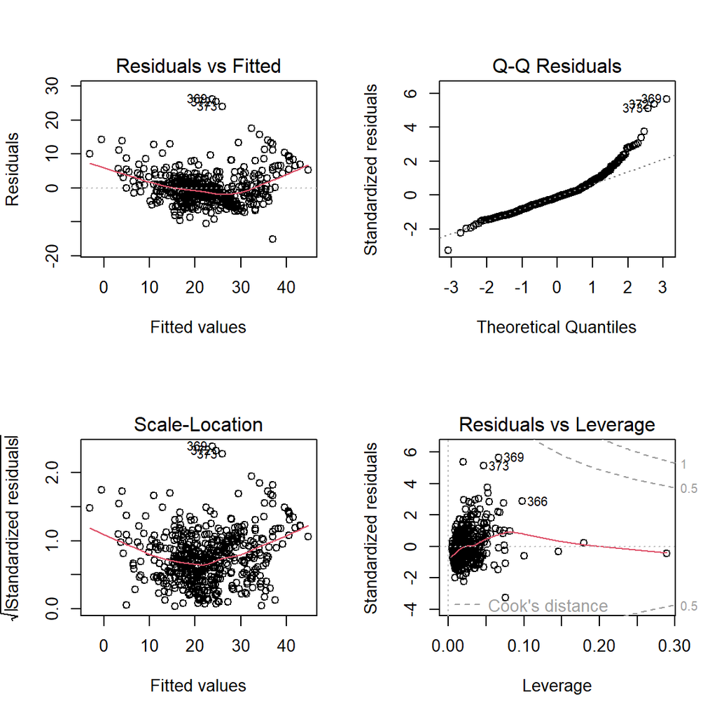

```r
par(mfrow=c(2,2))
plot(mod2)
```

```r
mod3 = lm(class ~ ., data = new_housing_without_age)
summary(mod3)
```

```
##
## Call:
## lm(formula = class ~ ., data = new_housing_without_age)
##
## Residuals:
##      Min       1Q   Median       3Q      Max
## -15.1846  -2.7326  -0.6111   1.8559  26.3831
##
## Coefficients:
##               Estimate Std. Error t value Pr(>|t|)
## (Intercept)  41.525878   4.919706   8.441 3.52e-16 ***
## CRIM         -0.121428   0.032969  -3.683 0.000256 ***
## ZN            0.046510   0.013766   3.379 0.000786 ***
## INDUS         0.013445   0.062086   0.217 0.828649
## CHAS          2.852877   0.867910   3.287 0.001084 **
## NOX         -18.485877   3.713727  -4.978 8.90e-07 ***
## RM            3.681071   0.411228   8.951  < 2e-16 ***
## DIS          -1.506786   0.192568  -7.825 3.11e-14 ***
## RAD           0.287934   0.066626   4.322 1.87e-05 ***
## TAX          -0.012652   0.003796  -3.333 0.000923 ***
## PTRATIO      -0.934679   0.131654  -7.100 4.38e-12 ***
## LSTAT        -0.547404   0.047669 -11.483  < 2e-16 ***
## ---
## Signif. codes:  0 '***' 0.001 '**' 0.01 '*' 0.05 '.' 0.1 ' ' 1
##
## Residual standard error: 4.794 on 494 degrees of freedom
## Multiple R-squared:  0.7343, Adjusted R-squared:  0.7284
## F-statistic: 124.1 on 11 and 494 DF,  p-value: < 2.2e-16
```

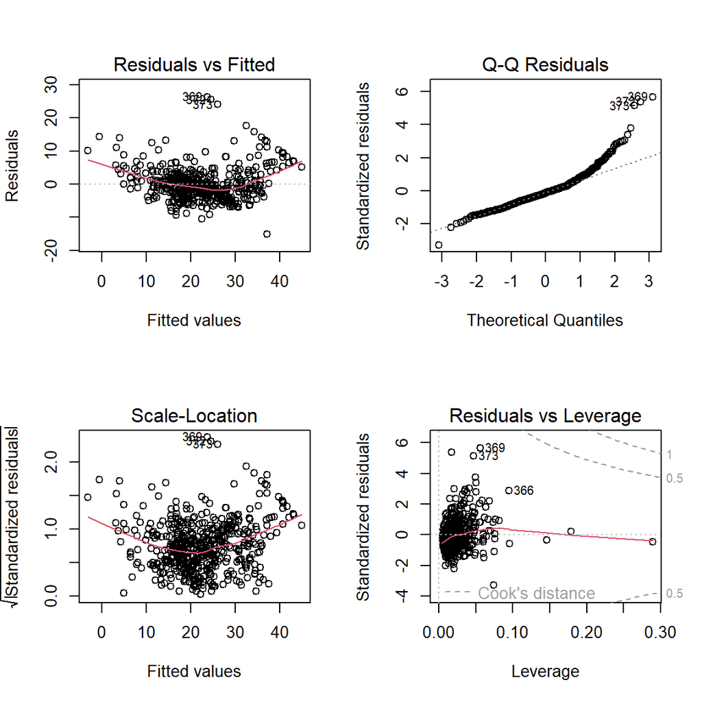

```r
par(mfrow=c(2,2))
plot(mod3)
```

```r
mod4 = lm(class ~ ., data = new_housing_without_both)
summary(mod4)
```

```
##
## Call:
## lm(formula = class ~ ., data = new_housing_without_both)
##
## Residuals:
##      Min       1Q   Median       3Q      Max
## -15.1809  -2.7623  -0.6239   1.8454  26.3913
##
## Coefficients:
##               Estimate Std. Error t value Pr(>|t|)
## (Intercept)  41.452529   4.903305   8.454 3.17e-16 ***
## CRIM         -0.121667   0.032919  -3.696 0.000244 ***
## ZN            0.046190   0.013673   3.378 0.000787 ***
## CHAS          2.871969   0.862589   3.329 0.000935 ***
## NOX         -18.263334   3.565266  -5.123 4.33e-07 ***
## RM            3.672962   0.409125   8.978  < 2e-16 ***
## DIS          -1.515957   0.187672  -8.078 5.07e-15 ***
## RAD           0.283927   0.063945   4.440 1.11e-05 ***
## TAX          -0.012291   0.003407  -3.608 0.000340 ***
## PTRATIO      -0.930993   0.130423  -7.138 3.39e-12 ***
## LSTAT        -0.546504   0.047442 -11.519  < 2e-16 ***
## ---
## Signif. codes:  0 '***' 0.001 '**' 0.01 '*' 0.05 '.' 0.1 ' ' 1
##
## Residual standard error: 4.789 on 495 degrees of freedom
## Multiple R-squared:  0.7342, Adjusted R-squared:  0.7289
## F-statistic: 136.8 on 10 and 495 DF,  p-value: < 2.2e-16
```

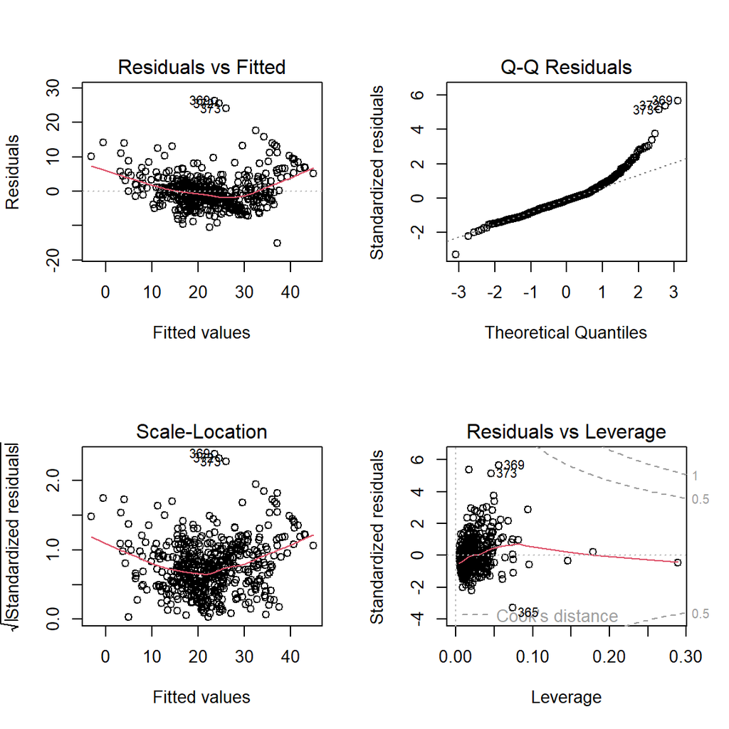

```r
par(mfrow=c(2,2))
plot(mod4)
```

5/ On remarque qu’il y a toujours des effets de correlation mais ceux ci sont faibles. Et lorsque l’on supprime l’un des deux paramètres les autres restent non-significatifs. Le modèle obtenu est satisfaisant, les p-value sont faibles pour chaque résidu et on a bien une p-value faible pour le modèle et le R carré ajusté a augmenté tandis que le R carré a légérement diminué.

On peut utiliser le critère de Bayes pour selectionner le meilleur des modèles défini précédemment :

```r
# Calcul du BIC pour ce modèle
bic_modele1 <- BIC(mod1)
bic_modele2 <- BIC(mod2)
bic_modele3 <- BIC(mod3)
bic_modele4 <- BIC(mod4)
print(c(bic_modele1, bic_modele2,bic_modele3,bic_modele4))
```

```
## [1] 3096.990 3090.811 3090.838 3084.660
```

Le BIC est le meilleur pour le modèle 4 c’est donc le meilleur ici(meilleur compromis entre ajustement et complexité).

6/ Pour améliorer le modèle linéaire initial, nous avons introduit des interactions entre certaines variables ainsi que des termes quadratiques afin de capturer des relations plus complexes et non linéaires entre les prédicteurs. En particulier, nous avons sélectionné les interactions entre `RM` (nombre moyen de pièces) et `LSTAT` (pourcentage de population à faible statut économique), `NOX` (concentration en oxyde nitreux) et `DIS` (distance aux centres d’emploi), ainsi que `PTRATIO` (ratio élèves/enseignant) et `LSTAT`. Ces variables ont été choisies car elles sont susceptibles d’avoir des effets combinés sur le prix des logements, notamment en lien avec la qualité de vie, l’accès aux services et l’influence de la composition socio-économique des quartiers. De plus, des termes quadratiques pour `RM` et `LSTAT` ont été ajoutés pour explorer des effets potentiellement non linéaires, où l’impact marginal de ces variables pourrait changer à des niveaux extrêmes. Ces ajustements permettent d’améliorer la précision du modèle en capturant des dynamiques plus complexes entre les facteurs influençant le marché immobilier:

```r
# Ajout des combinaisons linéaires et des termes quadratiques
Housing$RM_LSTAT = Housing$RM * Housing$LSTAT
Housing$PTRATIO_LSTAT = Housing$PTRATIO * Housing$LSTAT
Housing$RM_squared = Housing$RM^2
Housing$LSTAT_squared = Housing$LSTAT^2
Housing$NOX_DIS <- Housing$NOX * Housing$DIS

# Definition du modèle
best_mod =  lm(class ~ CRIM + ZN + CHAS + NOX + RM + DIS + RAD + TAX + PTRATIO + LSTAT +
                      RM_LSTAT + NOX_DIS + PTRATIO_LSTAT + RM_squared + LSTAT_squared, data = Housing)

summary(best_mod)
```

```
##
## Call:
## lm(formula = class ~ CRIM + ZN + CHAS + NOX + RM + DIS + RAD +
##     TAX + PTRATIO + LSTAT + RM_LSTAT + NOX_DIS + PTRATIO_LSTAT +
##     RM_squared + LSTAT_squared, data = Housing)
##
## Residuals:
##     Min      1Q  Median      3Q     Max
## -26.802  -2.400  -0.238   1.850  25.946
##
## Coefficients:
##                 Estimate Std. Error t value Pr(>|t|)
## (Intercept)    84.029023  15.376494   5.465 7.39e-08 ***
## CRIM           -0.165165   0.028390  -5.818 1.08e-08 ***
## ZN              0.020460   0.013393   1.528 0.127227
## CHAS            2.292072   0.723868   3.166 0.001639 **
## NOX           -13.952366   4.868653  -2.866 0.004339 **
## RM            -14.568760   3.938176  -3.699 0.000241 ***
## DIS            -0.714060   0.856914  -0.833 0.405086
## RAD             0.251337   0.055114   4.560 6.46e-06 ***
## TAX            -0.009094   0.002965  -3.067 0.002280 **
## PTRATIO        -0.400370   0.204280  -1.960 0.050573 .
## LSTAT           0.384703   0.546225   0.704 0.481584
## RM_LSTAT       -0.166005   0.058768  -2.825 0.004924 **
## NOX_DIS        -1.140866   1.874904  -0.608 0.543143
## PTRATIO_LSTAT  -0.021727   0.015068  -1.442 0.149974
## RM_squared      1.551078   0.273433   5.673 2.41e-08 ***
## LSTAT_squared   0.012334   0.004594   2.685 0.007504 **
## ---
## Signif. codes:  0 '***' 0.001 '**' 0.01 '*' 0.05 '.' 0.1 ' ' 1
##
## Residual standard error: 3.991 on 490 degrees of freedom
## Multiple R-squared:  0.8173, Adjusted R-squared:  0.8117
## F-statistic: 146.1 on 15 and 490 DF,  p-value: < 2.2e-16
```

```r
# Calcul du BIC pour ce modèle
bic_best_model <- BIC(best_mod)
print(c(bic_best_model))
```

```
## [1] 2926.25
```